# Forecasting Energy Demand for Extreme Low Temperature Events in Texas

Judy Zhu, Ruoxi Wu, Zhaoxin Zhang

2024-12-10

# 1 Rationale and Research Questions – Background

The 2021 Texas winter storm was a severe event that caused widespread power outages, major damage, and significant hardship for many people. With temperatures dropping as low as -2°F (-19°C), the storm pushed the state’s energy systems beyond their capacity. The combination of extreme cold and infrastructure failures showed how unprepared the system was for such events. This highlights the need to better understand cold weather extremes and their impact on energy systems to reduce risks and improve reliability during future storms.

Our research focuses on studying how often extreme cold events happen in Texas and how they affect local energy demand and electricity prices. By looking at past 8 years of temperature and energy data, we hope to find patterns and trends that can help predict grid demand during future cold days. This information can support better planning and help ensure Texas is more prepared to handle similar events in the future. Our goal is to improve resilience and energy security for the state during winter.

# 2 Research Questions:

1. How did the frequency of extreme cold days changed in the past 8 years in Texas? How did local energy demand and electricity price changed in these extreme cold days?
2. If following the past trend, how much energy will be demanded for preparing extreme cold days in 2024 and 2025?

# 3 Dataset Information

Data used for this analysis is from different sources. Historical records of temperature were found in the archive API https://archive-api.open-meteo.com/v1/era5. Given the information on Texas’s latitude and longitude and the start and end dates from January 2016 to December 2023, the API archive could provide data on daily temperature in Texas from 2016 to 2023. The API gave the maximum and minimum temperatures in Texas from 2016 to 2023 in degrees Celsius. The Electric Reliability Council of Texas (ERCOT) gave hourly energy load data in Texas, from year 2016 to 2023, in MW. The U.S. Energy Information Administration (EIA) contained monthly average electricity price data from 2001 to 2024, and the unit was cent/kWh. The data for daily electricity prices was unavailable. All of the data from the three sources used in this analysis had a date column, which could ensure the time series analysis’s viability. The data had continuous data on daily temperature, hourly load, and monthly price, which would be used for both time series and linear model analysis. The data and sources are listed below (Table 3.1).

Table 3.1: Table summarizing the data sources

| Sources | Data |
| --- | --- |
| API | Texas Daily Max and Min Temperature |
| ERCOT | Texas Hourly Energy Load |
| EIA | Texas Monthly Electricity Price |

# 4 Data Wrangling

The API data contained three columns: date, daily max temperature, and daily min temperature. The date column was in “character” format and thus needed to be converted to “date” format using the as.Date() code for the following analysis.

The raw ERCOT data contained hourly energy load data, but the analysis needed to be done at the daily level of energy load. Thus, the ERCOT’s data was aggregated and converted from hourly data to daily data. The ERCOT data had 10 columns: Date and Hourly Energy Load in MW via 9 different regions or standards. The analysis chose to use the ERCOT column, which represents total energy load by ERCOT’s service in Texas, selecting only two columns from the data: Date and ERCOT. The official website did not provide aggregated data from 2016 to 2023. Instead, it provided each year’s data. The data from 2016 to 2023 was aggregated in one data called “EnergyLoad_Daily.” This data would be used for analysis and visualization. Daily energy load data was then aggregated into monthly data for later analysis.

Finally, for electricity price, the EIA’s data contains 8 variables, including the date and electricity price via different end-use. This analysis would use the average electricity price for all sectors, so only two columns were selected: Date and Average Electricity Price among All Sectors. The data included information from 2001 to 2024, while the analysis only needed data from 2016 to 2023. Therefore, we filtered data from row 15 to row 96, selecting date only from 2016 to 2023.

All the data’s Date columns were converted to “date” format, and all other columns were converted to “numeric” format to make the latter analyses available. The raw data was uploaded to the “Data/Raw” file, and the processed datasets: monthly electricity price, daily energy load, monthly energy load, and daily temperature, were uploaded to the “Data/Processed” file in CSV format for the visualization, linear model analysis, and time series analysis. Please see DataWrangling.Rmd for details in preliminary data wrangling.l

# 5 Exploratory Analysis

## 5.1 Extreme cold days in Texas from 2016-2023

> Below is a column graph of all of the months’ # of days below 0 degree

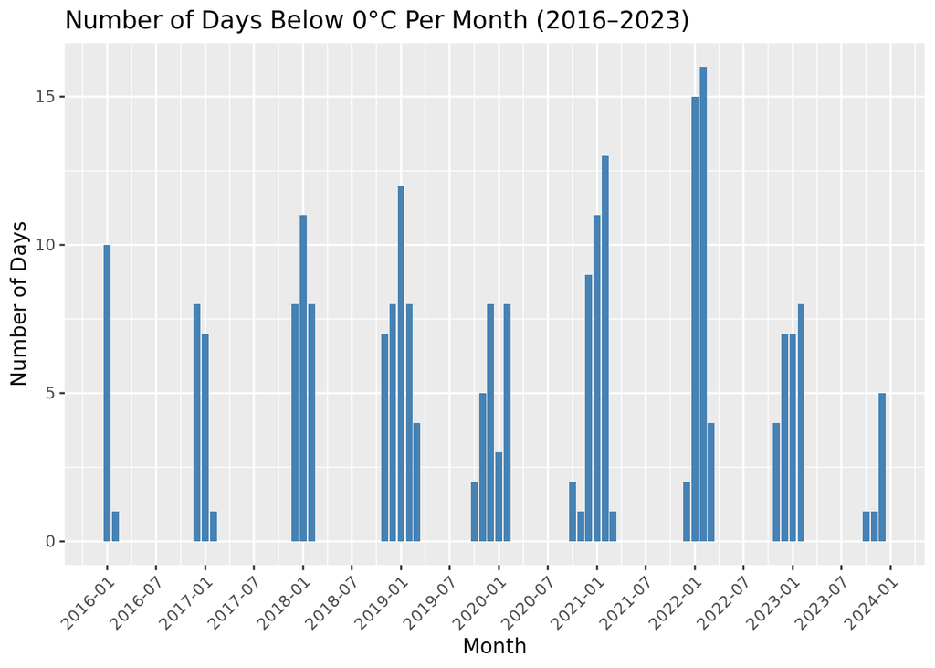

## 5.2 Energy Load in Texas from 2016-2023

> According to the line graph from 2016 to 2023, the energy load is generally increasing overtime with great pattern of seasonality, and it has spiked in mid-2023. General trend will be explained later in time series analysis.

> Below is a line of graph for Monthly load from 2016-2023

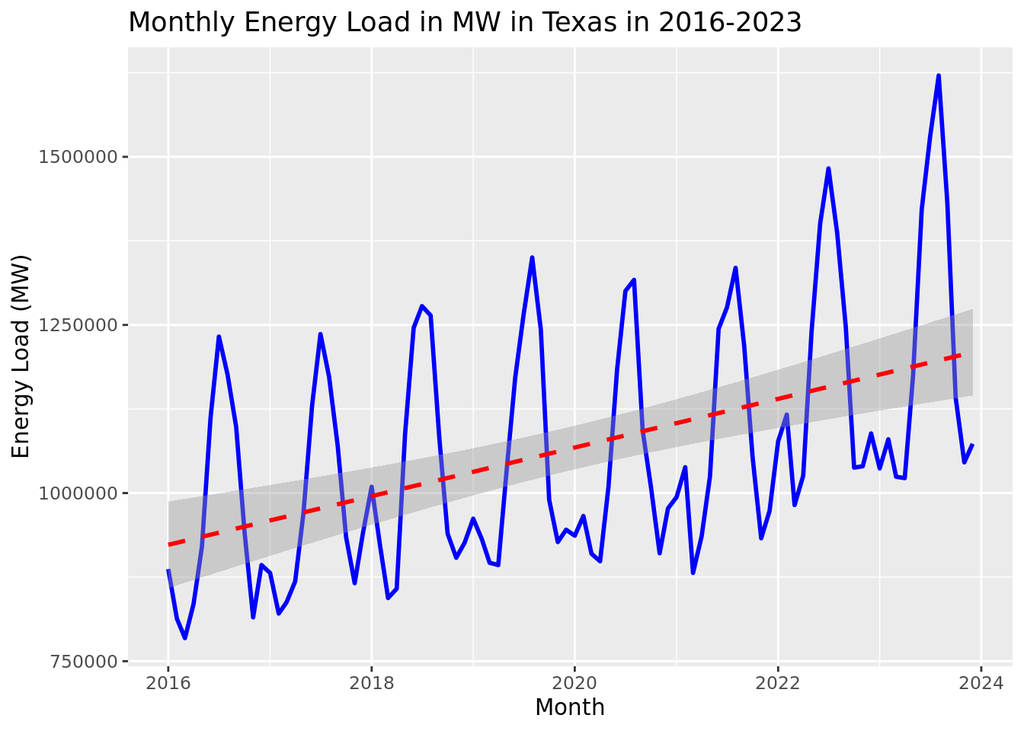

```r
ggplot(combined_data, aes(x = month, y = MW)) +
  geom_line(color = "blue", size = 1) +  # Line graph
  geom_smooth(method = "lm", color = "red", linetype = "dashed") +  # Add regression line
  labs(
    title = "Monthly Energy Load in MW in Texas in 2016-2023",
    x = "Month",
    y = "Energy Load (MW)")
```

## 5.3 Monthly electricity price in Texas from 2016-2023

> The electricity price in Texas is increasing overtime from 2016-2023 with slight but less consistent seasonality. However, the electricity price spike around early 2021, which could be a reflection from the large-scale blackout in the winter in Texas. The state-wide grid and local distribution systems were struggling to recover to cater the demand from the local residents and business during and right after the cold-front.

> Below is a line graph for monthly electricity price from 2016-2023

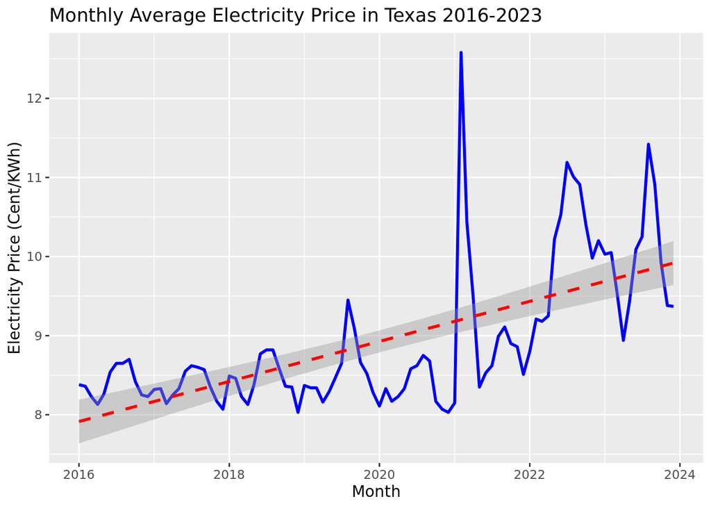

# 6 Analysis

## 6.1 Question 1: How did the frequency of extreme cold days changed in the past 8 years in Texas? How does this correlates with energy load and electricity price?

### 6.1.1 Frequency of extreme cold days:

We used linear models analysis to find how frequency of extremely cold days impacts energy load and electricity price. The analysis shows if the frequency of extreme cold days impacts energy load and electricity price or not. The report first analyzed the cold day frequency and energy load.

Table 1 Hypotheses

| Hypothesis |  |
| --- | --- |
| H0 | The frequency of extremely cold days in a month has no impacts on the average amount of monthly energy load |
| Ha | The frequency of extremely cold days in a month has impacts on the average amount of monthly energy load |

Table 2 Results

```
##                        Parameter       Value
## 1                        P-Value 4.38000e-03
## 2         Intercept Estimate Std 8.73984e+05
## 3 Extreme_Cold_days Estimate Std 1.19200e+04
```

The P-value is 0.00438, which is smaller than the significance level 0.05, so we reject the null hypothesis that number of extreme cold days has no impact on energy load. There is strong evidence that cold day frequency has a significant effect on energy load. When there is no extreme cold day, the energy load is estimated to be 873,984 MW. For every one additional extreme cold day, the monthly average energy load increases by 11,920 MW.

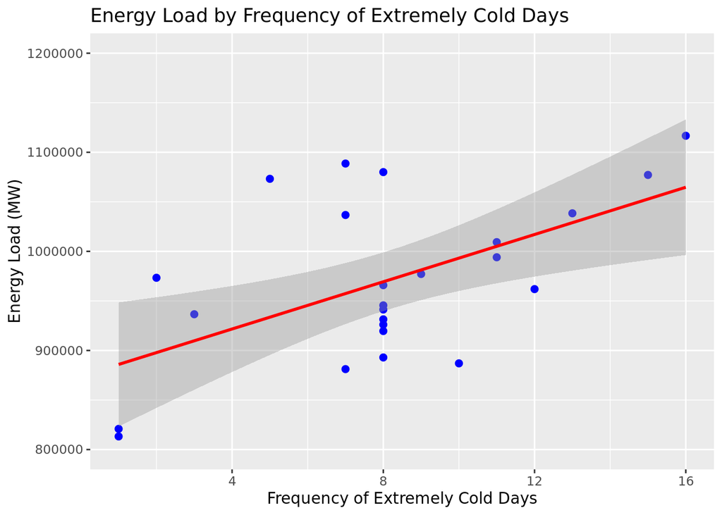

The report then analyzed the cold day frequency and electricity price and found that there is no strong evidence that cold day frequency has a significant effect on electricity price. The report then analyzed the impact of energy load on electricity price.

Table 3 Hypotheses

| Hypothesis |  |
| --- | --- |
| H0 | The average energy load in a month has no impacts on the monthly electricity price |
| Ha | The average energy load in a month has impacts on the monthly electricity price |

Table 4 Results

```
##                        Parameter     Value
## 1                        P-Value 9.220e-03
## 2         Intercept Estimate Std 1.450e+00
## 3 Extreme_Cold_days Estimate Std 7.772e-06
```

The p-value of energy load is 0.00922, which is smaller than the significance level 0.05, so we reject the null hypothesis that the average energy load in a month has no impacts on the monthly electricity price. There is strong evidence that the average energy load in a month has has a significant effect on electricity price. When the energy load is 0, the price will be 1.450e+00 cent, and for every one additional MW in energy load, the electricity price will increase by 7.772e-06 cent per MW.x

[output not shown]

[output not shown]

[figure not shown]

[output not shown]

[output not shown]

## 6.2 Question 2: How did local energy load and electricity price changed in these extreme cold days?

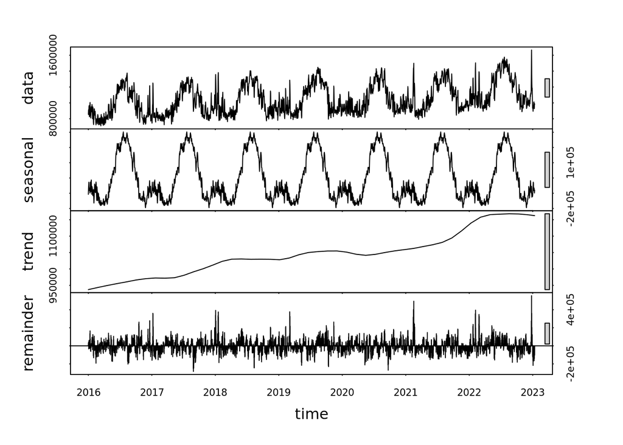

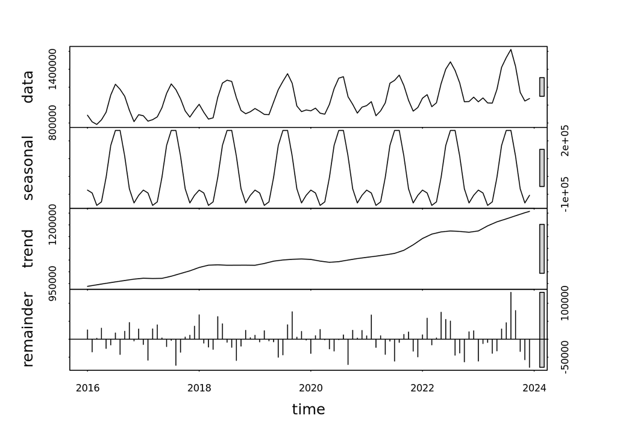

For electricity price, we also did time series analysis and seasonal Mann Kendall test; however, since electricity price is influenced by multiple factors aside from seasonality, such as market dynamics and policies, we also run a normal Mann Kendall test on de-trended electricity data.

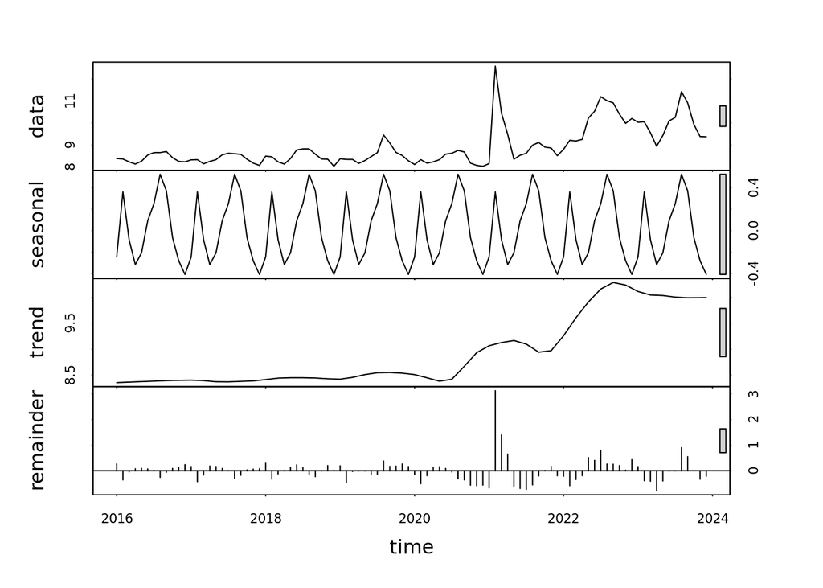

```
##         Parameter Seasonal_MannKendall Detrended_MannKendall
## 1           Score           1.6200e+02             2.112e+03
## 2 2-sided p-value           5.6949e-09             2.220e-16
```

As shown in the table, both test results shows that electricity price has significantly increased in the past 8 years.

## 6.3 Question 3: If following the past trend, how much energy will be demanded for preparing extreme cold days in 2024 and 2025?

Lastly, we hope to predict energy load in 2024 and 2025 based on historical data. We will use Autoregressive Integrated Moving Average (ARIMA) package to do a simple forecasting using historical energy load data from 2016 to 2023. However, daily energy load data will contain too much noise and excessive workload for the function to run; therefore, we choose to use averaged daily load of each months.

```r
energy.prediction <- auto.arima(energyload.daily.avg.ts, seasonal = TRUE)
summary(energy.prediction)
```

```
## Series: energyload.daily.avg.ts
## ARIMA(1,0,0)(0,1,1)[12] with drift
##
## Coefficients:
##          ar1     sma1      drift
##       0.5209  -0.7086  2898.7512
## s.e.  0.0923   0.1326   405.1377
##
## sigma^2 = 2.352e+09:  log likelihood = -1028.27
## AIC=2064.54   AICc=2065.05   BIC=2074.27
##
## Training set error measures:
##                     ME     RMSE     MAE        MPE     MAPE      MASE
## Training set -1132.929 44545.57 33263.4 -0.3189262 3.049786 0.6103982
##                    ACF1
## Training set 0.02517257
```

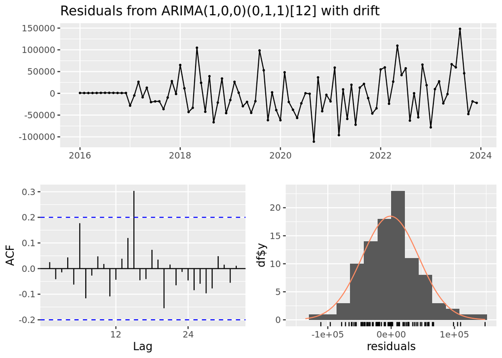

```
##
##  Ljung-Box test
##
## data:  Residuals from ARIMA(1,0,0)(0,1,1)[12] with drift
## Q* = 21.159, df = 17, p-value = 0.2193
##
## Model df: 2.   Total lags used: 19
```

```r
# Check residuals
checkresiduals(energy.prediction)
```

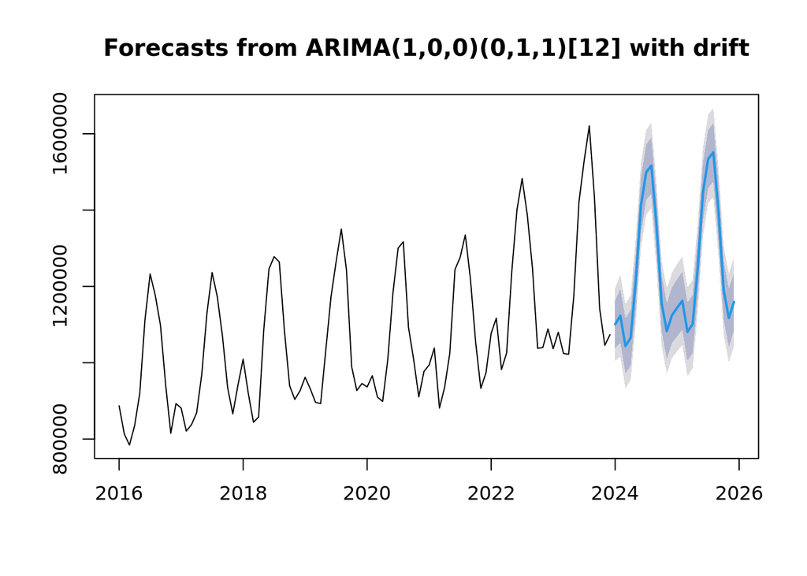

```r
# Forecast
energy.forecasted <- forecast(energy.prediction, h = 24)
plot(energy.forecasted)
```

```r
summary(energy.forecasted)
```

```
##
## Forecast method: ARIMA(1,0,0)(0,1,1)[12] with drift
##
## Model Information:
## Series: energyload.daily.avg.ts
## ARIMA(1,0,0)(0,1,1)[12] with drift
##
## Coefficients:
##          ar1     sma1      drift
##       0.5209  -0.7086  2898.7512
## s.e.  0.0923   0.1326   405.1377
##
## sigma^2 = 2.352e+09:  log likelihood = -1028.27
## AIC=2064.54   AICc=2065.05   BIC=2074.27
##
## Error measures:
##                     ME     RMSE     MAE        MPE     MAPE      MASE
## Training set -1132.929 44545.57 33263.4 -0.3189262 3.049786 0.6103982
##                    ACF1
## Training set 0.02517257
##
## Forecasts:
##          Point Forecast     Lo 80   Hi 80     Lo 95   Hi 95
## Jan 2024        1100597 1038368.6 1162826 1005426.7 1195768
## Feb 2024        1123036 1052886.6 1193186 1015751.6 1230321
## Mar 2024        1043820  971671.1 1115969  933477.6 1154163
## Apr 2024        1065355  992673.1 1138037  954197.5 1176513
## May 2024        1215851 1143025.2 1288677 1104473.4 1327229
## Jun 2024        1412050 1339184.4 1484915 1300611.9 1523487
## Jul 2024        1498934 1426058.0 1571809 1387480.0 1610388
## Aug 2024        1516809 1443930.3 1589687 1405350.7 1628267
## Sep 2024        1361644 1288764.3 1434523 1250184.4 1473103
## Oct 2024        1155566 1082686.8 1228445 1044107.1 1267024
## Nov 2024        1082586 1009709.5 1155463  971130.7 1194042
## Dec 2024        1124614 1051744.4 1197484 1013169.5 1236059
## Jan 2025        1144032 1068938.2 1219127 1029185.7 1258879
## Feb 2025        1162327 1086634.9 1238020 1046565.8 1278089
## Mar 2025        1080952 1005098.6 1156806  964944.0 1196961
## Apr 2025        1101363 1025465.4 1177260  985287.6 1217438
## May 2025        1251273 1175363.8 1327183 1135179.8 1367367
## Jun 2025        1447166 1371253.7 1523079 1331068.0 1563265
## Jul 2025        1533892 1457978.1 1609805 1417792.0 1649991
## Aug 2025        1551684 1475770.2 1627597 1435583.9 1667784
## Sep 2025        1396475 1320561.8 1472389 1280375.6 1512575
## Oct 2025        1190375 1114462.0 1266288 1074276.1 1306474
## Nov 2025        1117384 1041473.0 1193295 1001288.0 1233480
## Dec 2025        1159406 1083501.5 1235310 1043320.2 1275491
```

The ARIMA test result shows that for the incoming winter (December 2024, Janurary and Feburary 2025), daily energy load in a normal winter day in Texas is predicted at 1124614 to 1162327 MW. We are at 95% confidence for the actual energy loaded be as high as 1278089 MW in Feburary and as low as 1013169.5 in December.

# References